# v2 Integrating Data and Generating UMAP

D. Ford Hannum Jr.

8/24/2020

```r
knitr::opts_chunk$set(echo = FALSE, message = FALSE)
library(Seurat)
library(ggplot2)
library(data.table)
library(MAST)
library(SingleR)
library(dplyr)
library(tidyr)
library(limma)
```

# Introduction

In v2 of the analysis we decided to include the control mice from the Nbeal experiment with the Migr1 and Mpl mice. The thought is that it may be good to have another control, since the Migr1 control has irradiated and had a bone marrow transplantation. I’m going to split the Rmarkdown files into separate part, to better organize my analysis.

## This File

Here the control from the Nbeal and the data from the Migr1/Mpl experiment are going to be integrated together and we are going to do all the normalization, scaling, and data reduction. I’m following the [integration guide](https://satijalab.org/seurat/v3.2/integration.html) from the Satija Lab and some of my previous files (integrating_with_hwbm_to…)

# Loading the data and getting HTO labels

Loading the raw matrices supplied by 10X for the two experiment and find the cells that have an HTO

## Migr1/Mpl Experiment

We started out with **11,278** cells in the experiment. After a basic filtering when creating the Seurat object (minimum of 200 features, also filtered for genes that were expressed in a minimum of 3 cells) we had **10,157** cells. There were only **7,542** cells that had an HTO label, of which **7,228** passed the basic Seurat filtering.

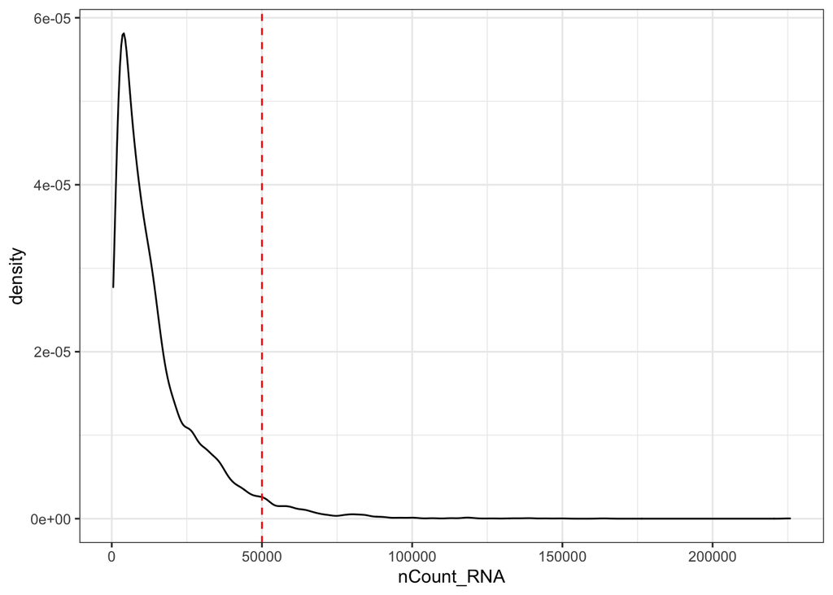

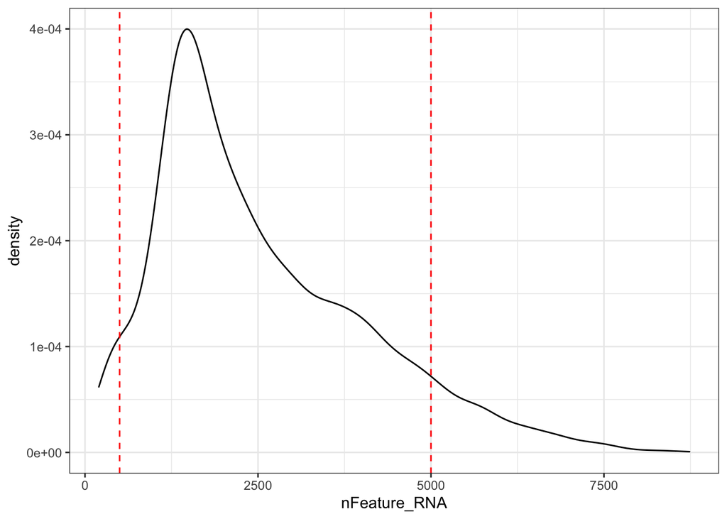

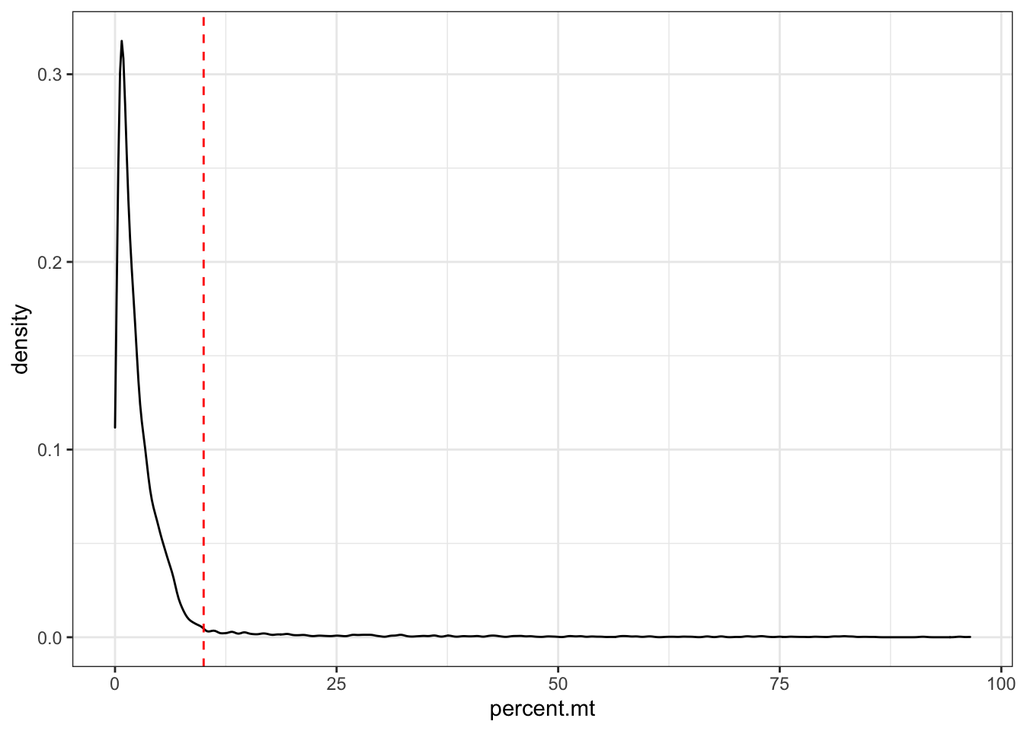

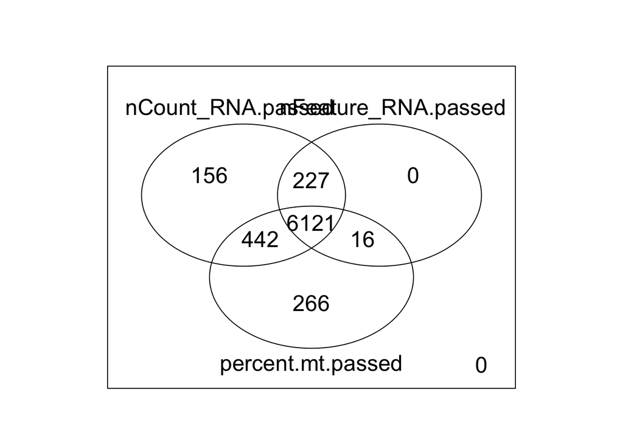

Dashed lines indicate cutoffs I used for subsetting the Seurat dataset. We end up with **6,121** cells for the Migr1/Mpl experiment. Venn diagram is just for our use, and can be made nicer if we wish to publish something like that.

## Nbeal Controls

We started **6,376** that passed basic Seurat filtering, and **1,991* were labeled with either the HTO3 or HTO4 tag, which indicates they came from the control mouse.

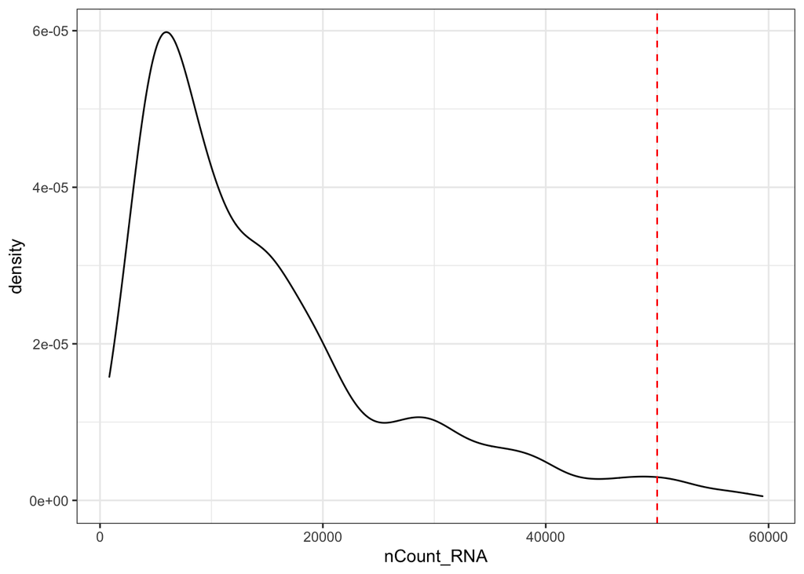

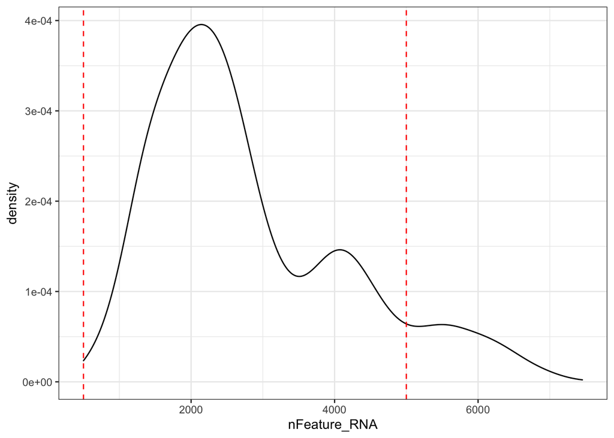

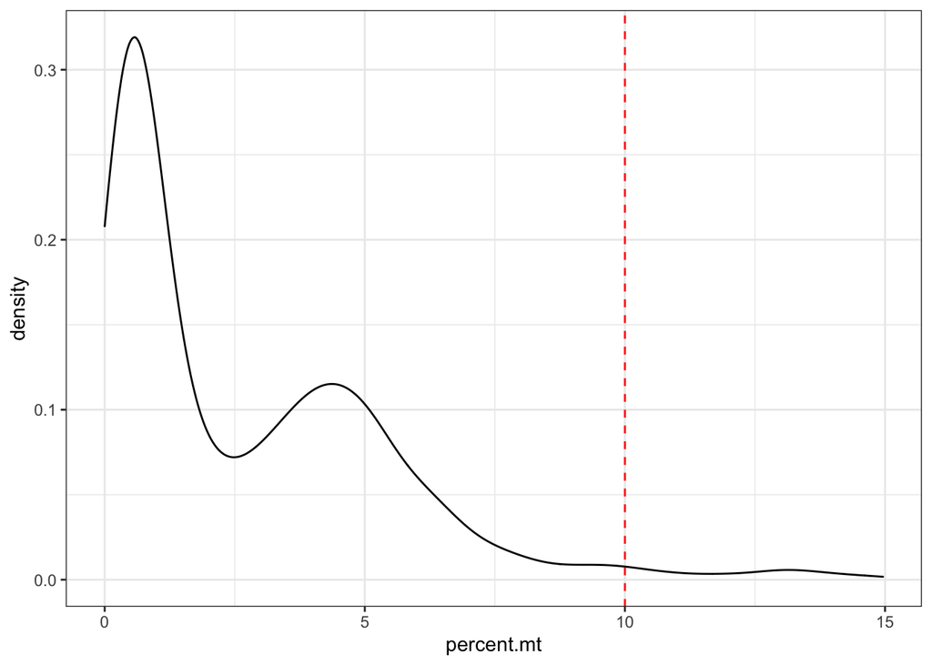

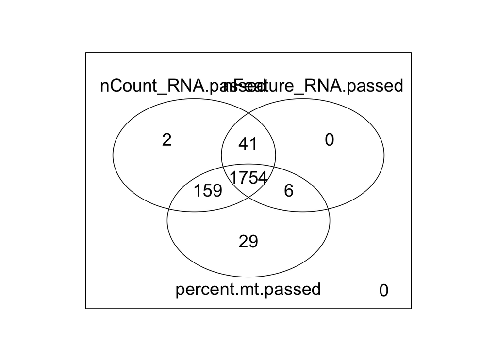

We end up with **1,754** control cells from the Nbeal experiment (normal and enriched).

# Integrating the datasets

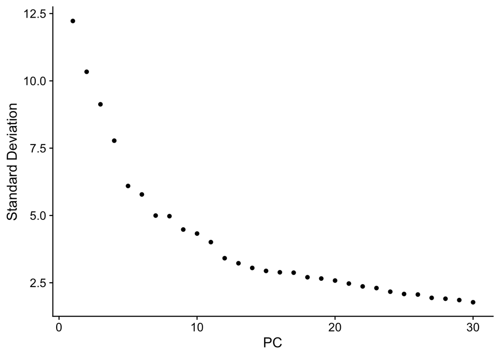

```
## [1] "Going with the first 20 PCs"
```

[output not shown]

[output cut: 134 more lines]

[output not shown]

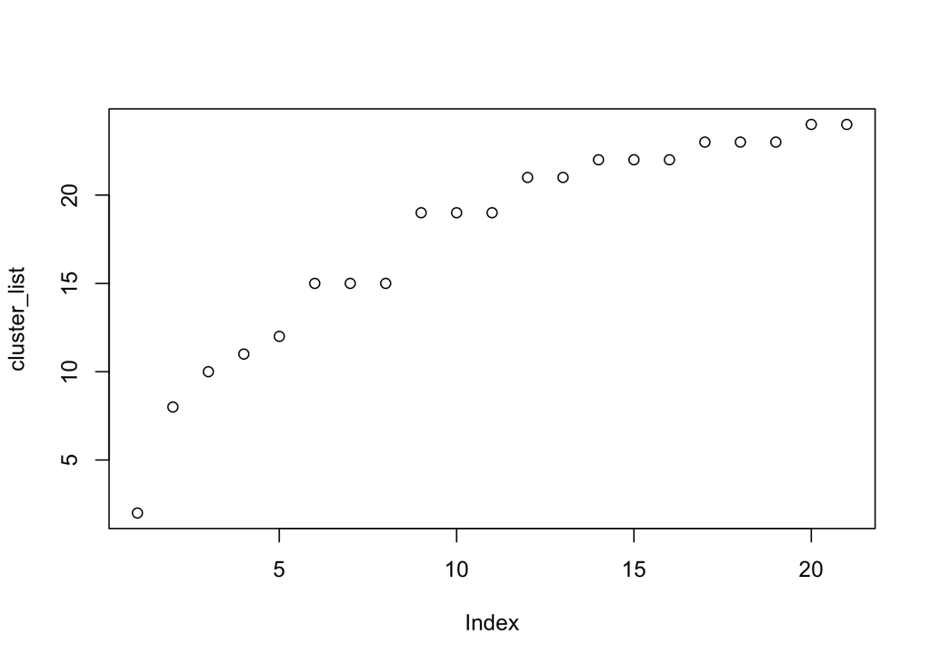

```
## [1] "Going with index 7 = 0.3"
```

```
## Modularity Optimizer version 1.3.0 by Ludo Waltman and Nees Jan van Eck
##
## Number of nodes: 7875
## Number of edges: 329769
##
## Running Louvain algorithm...
## Maximum modularity in 10 random starts: 0.9453
## Number of communities: 15
## Elapsed time: 0 seconds
```

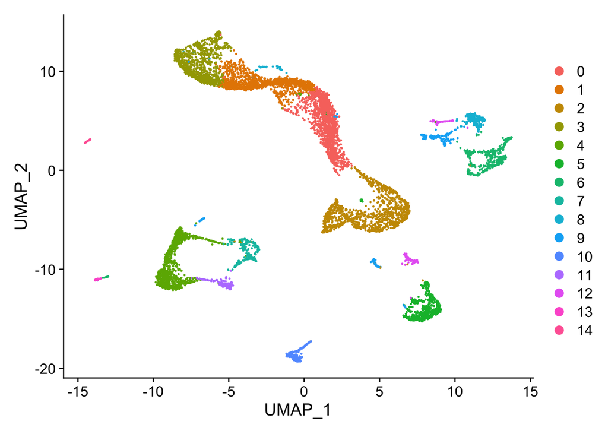

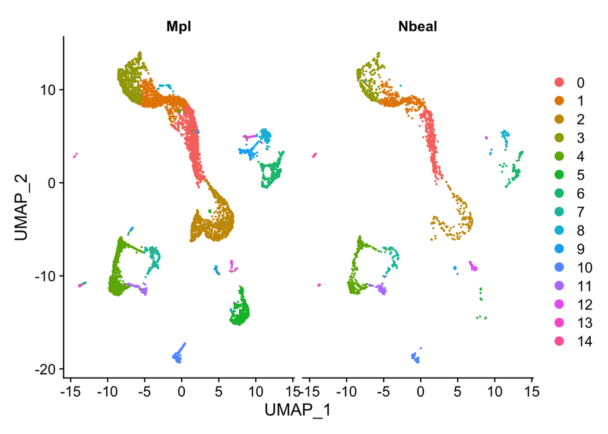

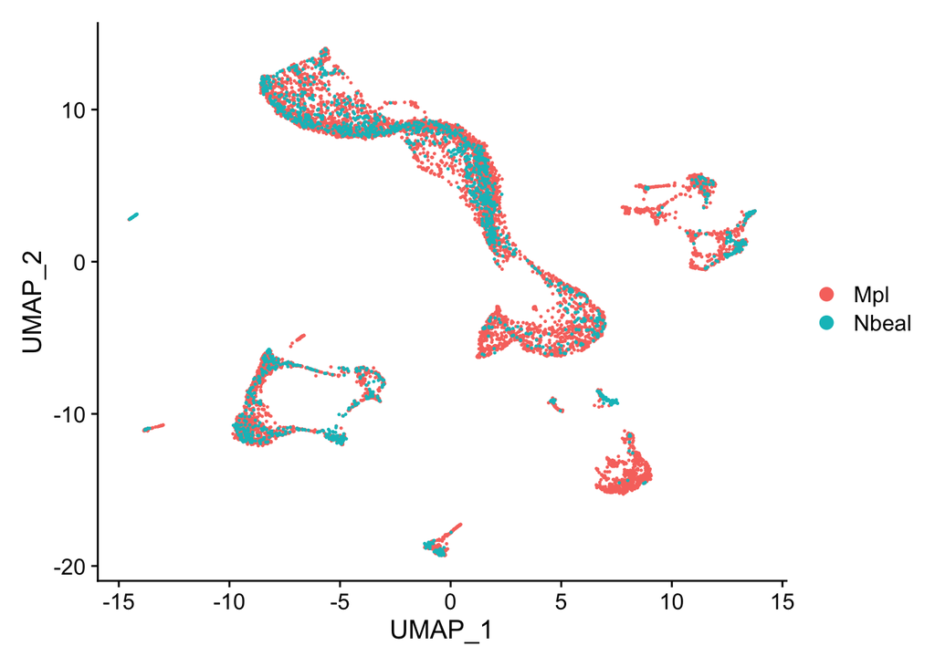

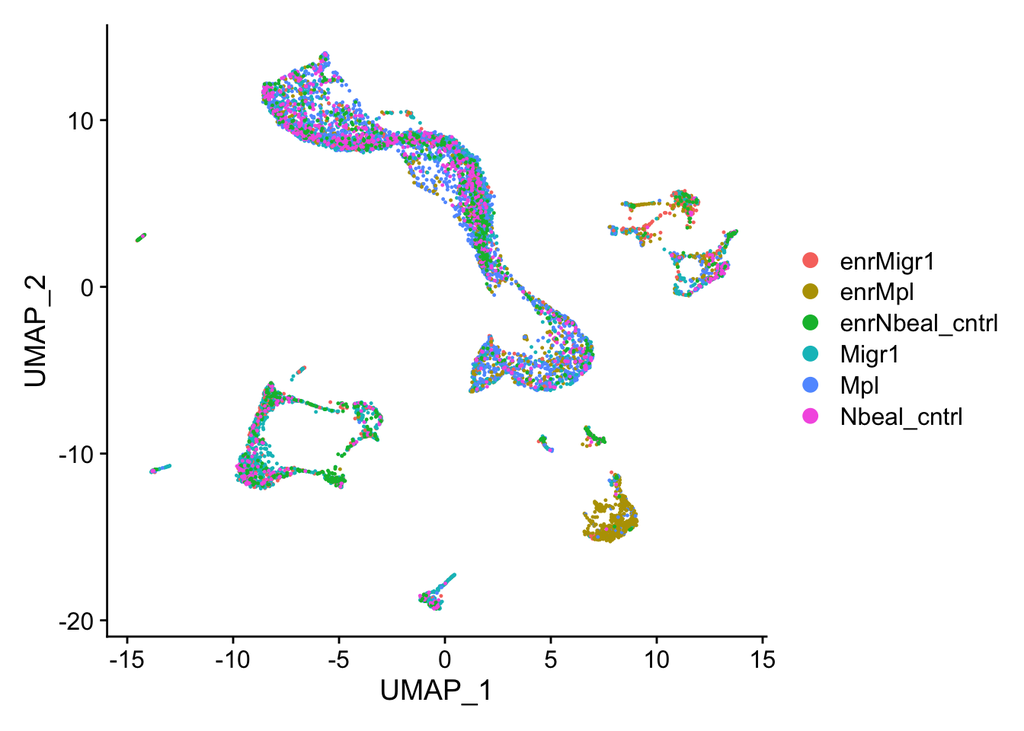

```
##                        orig.ident nCount_RNA nFeature_RNA Condition percent.mt
## Mpl_AAACCCAAGAGGCTGT-1        Mpl       3727         1578  enrMigr1  7.8883821
## Mpl_AAACCCACATAAGATG-1        Mpl      13528         2333       Mpl  1.4784151
## Mpl_AAACCCAGTATGGTTC-1        Mpl      34657         4112     Migr1  1.1455117
## Mpl_AAACCCAGTGAGCGAT-1        Mpl      16305         2320    enrMpl  0.8095676
## Mpl_AAACCCAGTGGCTGCT-1        Mpl       1158          564       Mpl  6.3903282
## Mpl_AAACCCATCAATGTCG-1        Mpl       7493         1593       Mpl  0.4003737
##                        nCount_RNA.passed nFeature_RNA.passed percent.mt.passed
## Mpl_AAACCCAAGAGGCTGT-1              TRUE                TRUE              TRUE
## Mpl_AAACCCACATAAGATG-1              TRUE                TRUE              TRUE
## Mpl_AAACCCAGTATGGTTC-1              TRUE                TRUE              TRUE
## Mpl_AAACCCAGTGAGCGAT-1              TRUE                TRUE              TRUE
## Mpl_AAACCCAGTGGCTGCT-1              TRUE                TRUE              TRUE
## Mpl_AAACCCATCAATGTCG-1              TRUE                TRUE              TRUE
##                        integrated_snn_res.0.3 seurat_clusters
## Mpl_AAACCCAAGAGGCTGT-1                      4               4
## Mpl_AAACCCACATAAGATG-1                      0               0
## Mpl_AAACCCAGTATGGTTC-1                      2               2
## Mpl_AAACCCAGTGAGCGAT-1                      2               2
## Mpl_AAACCCAGTGGCTGCT-1                      3               3
## Mpl_AAACCCATCAATGTCG-1                      1               1
```

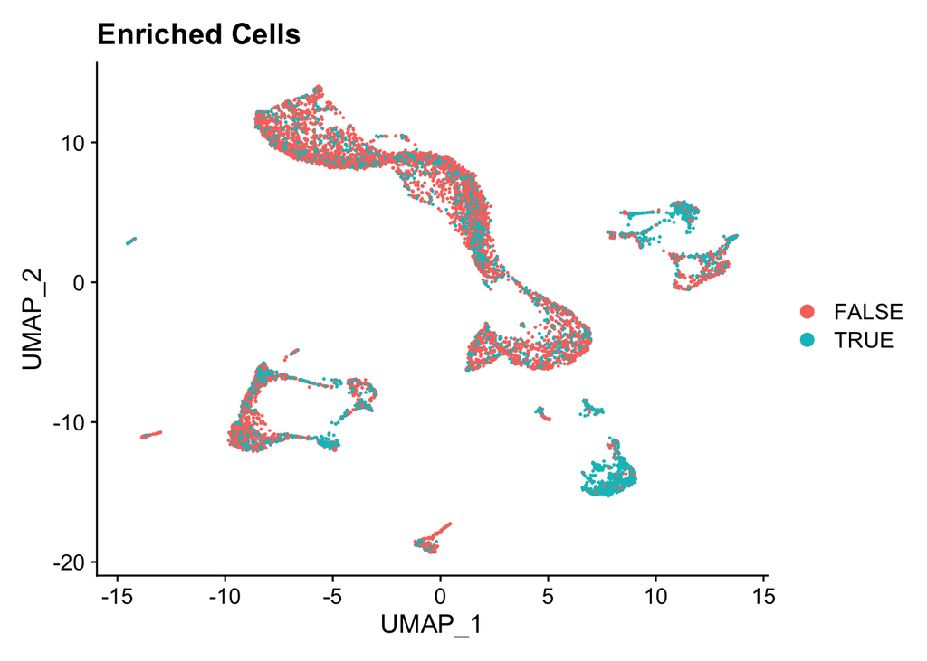